# Poisson point processes

First, let’s simulate raindrops on a field (of roses). The field will be 10m x 10m, with a mean intensity of $\lambda(r)$ drops of radius $r$ per minute per square meter, with
$$\lambda(r) = 1000 exp(-r) .$$

Therefore, the total rate of arrival of drops is 1000 per minute per square meter, i.e., $10^5$ per minute across the whole field. Let’s simulate this for $t$ minutes. The total number of drops that fall in this time is Poisson with mean $t \times 10^5$. Given this, each raindrop has an independently drawn radius from the distribution proportional to $\exp(-r)$, i.e., Exponential(1). Their locations are independent and uniform.

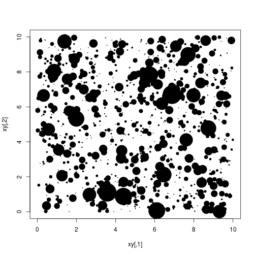

```r
W <- 10  # field size in meters
tmax <- 0.01  # in minutes
N <- rpois(1, tmax * W^2 * 1e3)
xy <- cbind(runif(N) * W, runif(N) * W)
r <- rexp(N)

plot(xy, cex=r, pch=21, bg='black')
```

# Markov chain

Consider the Markov chain on the integers that moves as follows. When at $n$, it jumps to $n/p$ with rate equal to $1/p$ for each prime $p$ that divides $n$, and it jumps to $np$ with rate equal to $1/p$ for each prime up to some maximum. The total jump rate out of $n$ is therefore
$$J(n) = \sum_{p|n} \frac{1}{p} + \sum_{p} \frac{1}{p} .$$

To simulate this, let’s first construct the generator matrix, $G$.

```r
library(Matrix)

N <- 1e4  # max size of the primes
divmat <- outer(2:N, 2:N, function (x,y) (y %% x) == 0)
primes <- 1L + which(colSums(divmat) == 1)
np <- length(primes)

M <- 1e5  # biggest number we go up to
p <- 2
G <- sparseMatrix(i=1:floor(M/p),
                  j=p*1:floor(M/p),
                  x=1/p,
                  dims=c(M,M))
for (p in primes[-1]) {
    G <- G + sparseMatrix(i=1:floor(M/p),
                          j=p*1:floor(M/p),
                          x=1/p,
                          dims=c(M,M))
}
G <- G + t(G)

dG <- rowSums(G)  # jump rates
```

Now let’s simulate. The chain at $n$ will (a) wait an Exponential amount of time with rate `dG[n]` and then choose a state to jump to with probability proportional to the corresponding row of $G$, i.e., `G[n,]`.

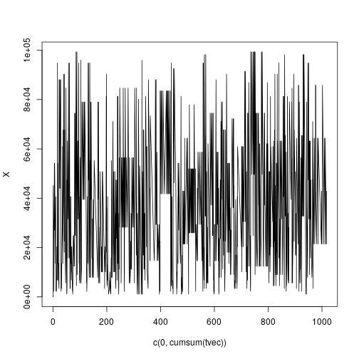

```r
p.to.j <- function (p) { rep( seq.int( length(p)-1 ), diff(p) ) }
Gj <- p.to.j(G@p) # column indices (1-based)
draw_from_row <- function (n) {
    # pick an entry from G[n,] with prob proportional to its value
    k <- (G@i + 1L == n)
    sample(Gj[k], size=1, prob=G@x[k])
}

nsteps <- 1000
X <- rep(NA, nsteps + 1)
X[1] <- 1
tvec <- rep(NA, nsteps)
for (k in 1:nsteps) {
    tvec[k] <- rexp(1, rate=dG[X[k]])
    X[k+1] <- draw_from_row(X[k])
}

plot(c(0, cumsum(tvec)), X, type='l')
```